# Health Report

A Review of Lee Kennedy’s Health

Lee Kennedy

2017-02-12

# Introduction

My weight and health parameters have been recorded, with varying levels of diligence, since about 2006.

I take no health related medications, relying entirely on diet and exercise to maintain health.

There are two goals of this report:

1. To chronicle my health, prompted recently by participation the the DTS Biggest Loser Challenge;
2. To practice R Markdown.

# Weight

My weight has fluctuated over the years, with a major reduction in 2013, which was a prelude to the Great Jill fiasco. It then climbed slowly over the next two years before participating in the DTS Biggest Loser Challenge.

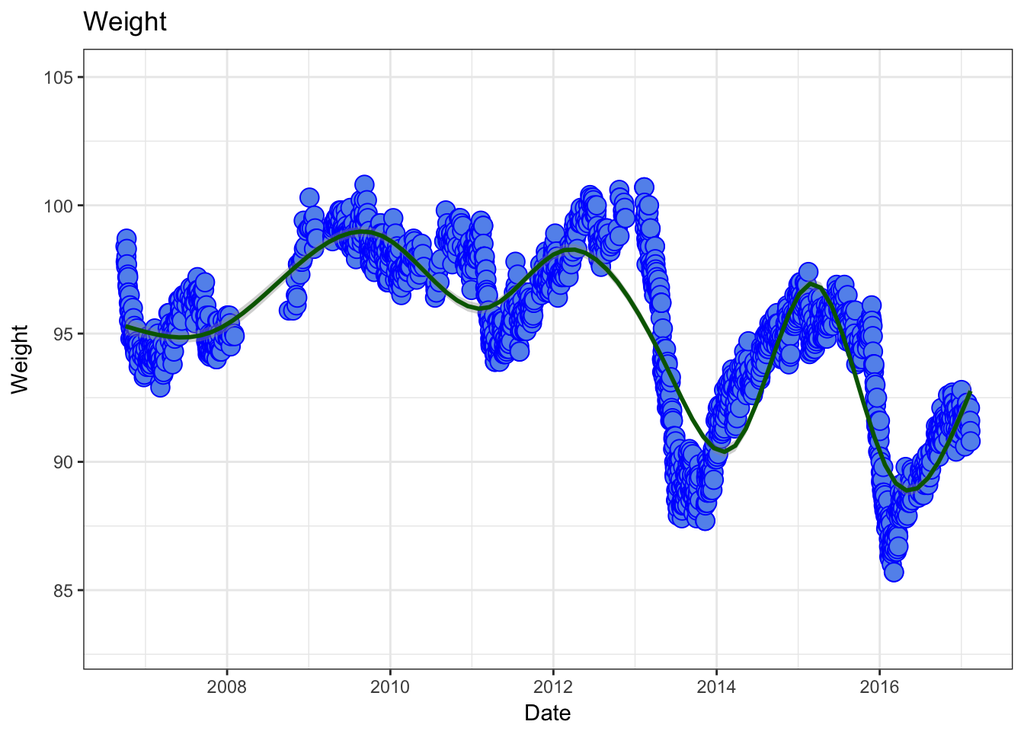

Looking more closely at that challenge and its impact on my weight, we see that, having peaked (or troughed) in early March there is a trend upwards. After my birthday effort must be put into reversing this trend:

March 29th

In this chart, the verticle dotted red line indicates the end of the DTS Biggest Loser Challenge. The horizontal dotted red line represents the weight at the start of the challenge.

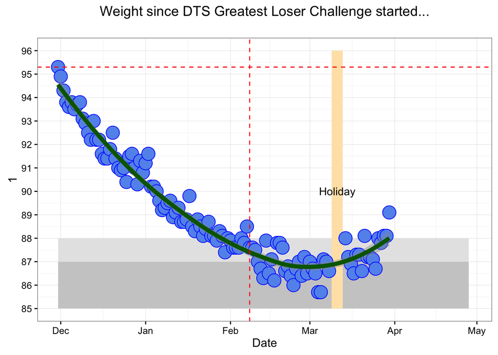

## Yearly Boxplot Snapshot

The yearly change is readily seen in a progressive boxplot:

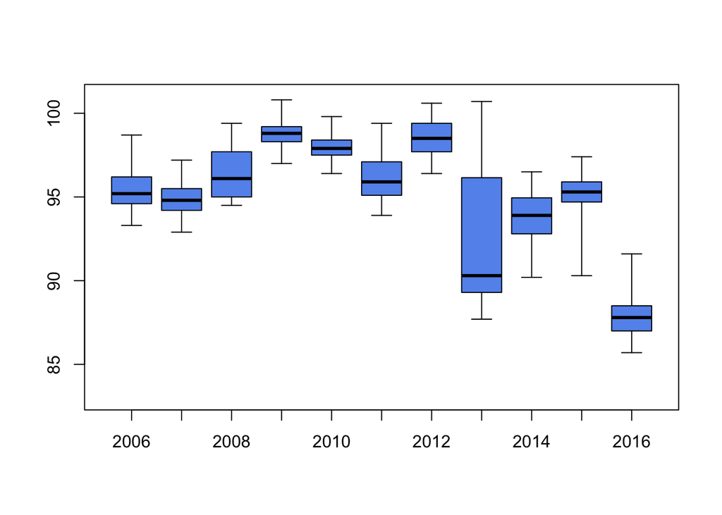

# Waist to Hip Ratio

One of the metrics that is monitored is the ‘waist to hip’ ratio. The general guideline is that, for a man, it should be less than 0.9.

# Blood Pressure

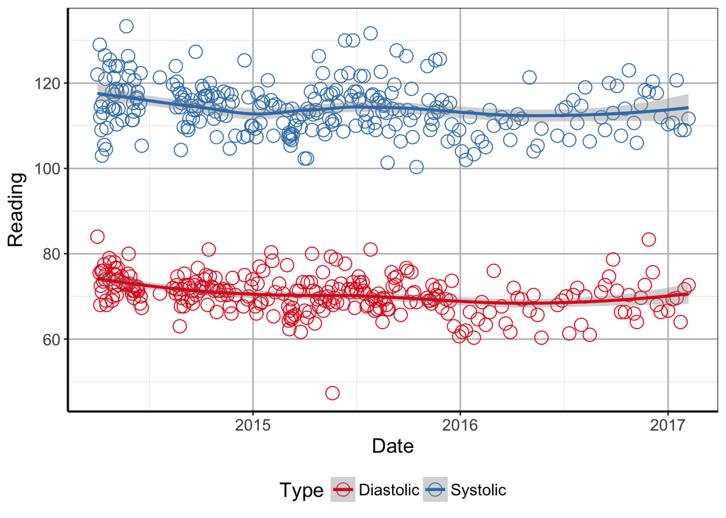

## Cholesterol

There was a period from 2008 - 2013 where I was convinced by my then doctor to take *Crestor*, a cholesterol lowering statin. In the end I decided I did not like the idea of taking a medication that altered the functioning of my liver. There is no denying that it worked, but at what cost? I am now using diet to control my cholesterol level.

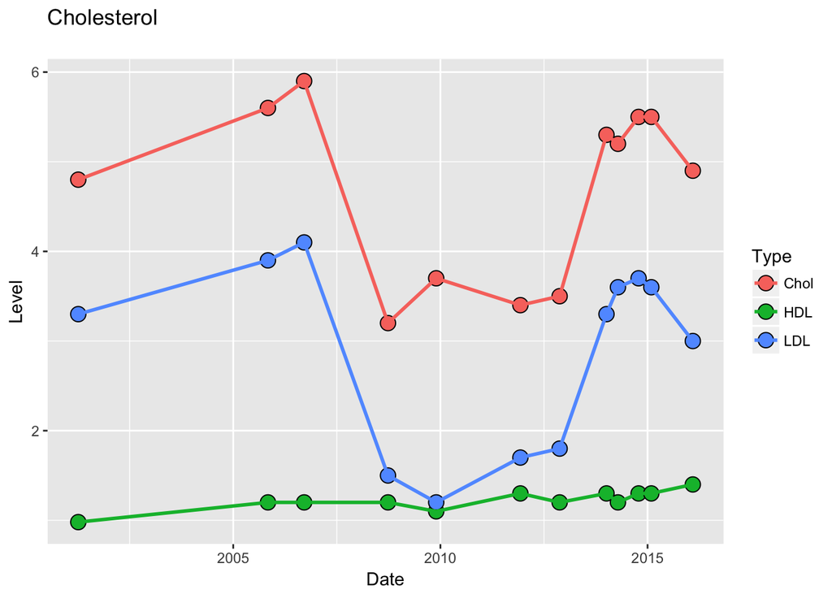

## Prostate Specific Antigen (PSA)

While opinions differs and it is considered not specific, this test is a possible marker for the possibility of prostate cancer. Median PSA levels for men over 60 is 1.2ug/L.

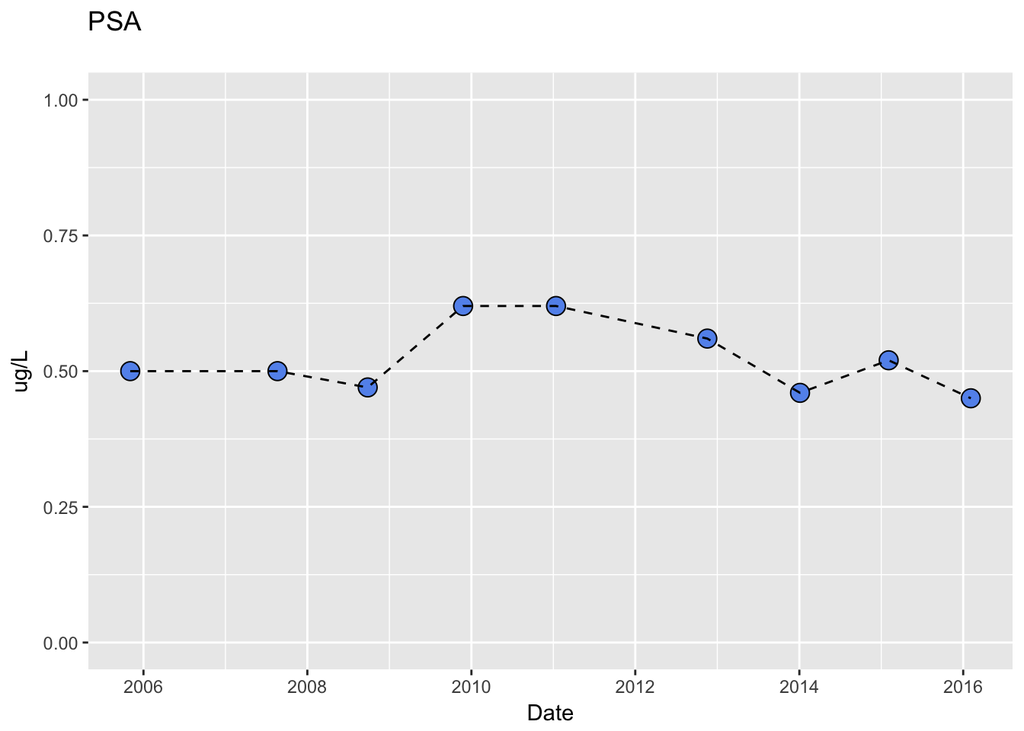